# Ungraded Assignment 2: OSC account setup

Deadline

August 30, 2026

Page last modified

August 23, 2026

### Overview

By Sunday, August 30<sup>th</sup>, you should ensure you can access the Ohio Supercomputer Center (OSC) and the OSC Project for this course (`PAS3493`).

*If you have any questions about this or run into problems while setting up your OSC account,* *contact Jelmer.*

### Why this is needed

Starting with next Monday’s class, you will do nearly all of your work for this course at OSC — and to do so, you’ll need an OSC account.

Earlier this week, you were added to the OSC Project for this course (`PAS3493`). Membership in this project allows you to access the course’s shared files and to reserve computing resources. If you didn’t already have an OSC account, being added to this project allows you to create one.

### What you should do

**If you don’t have an OSC account yet**

1. You should have received an email from OSC (no-reply@osc.edu) informing you that you were added to OSC Project `PAS3493`, with a link to create an account. Follow the instructions in the email to create your account.

   At some point during the course, you’ll have to type your password in a terminal, where you won’t be able to see what you are typing. We therefore recommend a password that is not extremely complicated or long.
2. Check that you can log in to OSC at https://ondemand.osc.edu using your OSC username and password (the login option on the left-hand side of the page). This typically works right away, but in some cases it *may* take up to half an hour after you create your account.

**If you already have an OSC account**

1. You should have received an email from OSC (no-reply@osc.edu) informing you that you were added to OSC Project `PAS3493`. Make sure you received this email — other than that, you don’t need to activate anything.
2. Check that you can log in to OSC at https://ondemand.osc.edu using your OSC username and password (the login option on the left-hand side of the page).

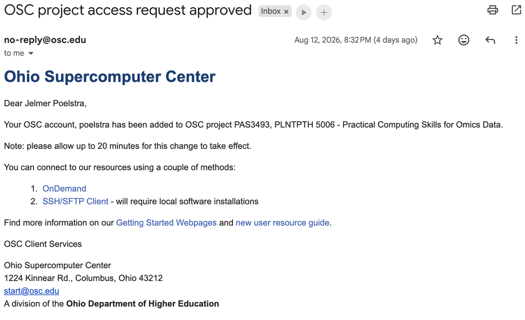

This is the kind of email you will receive from OSC when you’ve been added to an OSC project and already have an account. If you don’t have an account, you will receive a similar email but with a link to create one.

Back to top